# Deep Learning and PyTorch

## 12/2/2021

print view

```python
%%html
<script src="http://bits.csb.pitt.edu/asker.js/lib/asker.js"></script>
<script>

require(['https://cdnjs.cloudflare.com/ajax/libs/Chart.js/2.2.2/Chart.js'], function(Ch){
 Chart = Ch;
});

$('head').append('<link rel="stylesheet" href="http://bits.csb.pitt.edu/asker.js/themes/asker.default.css" />');


//the callback is provided a canvas object and data
var chartmaker = function(canvas, labels, data) {
  var ctx = $(canvas).get(0).getContext("2d");
     var dataset = {labels: labels,
    datasets:[{
     data: data,
     backgroundColor: "rgba(150,64,150,0.5)",
         fillColor: "rgba(150,64,150,0.8)",
  }]};
  var myBarChart = new Chart(ctx,{type:'bar',data:dataset,options:{legend: {display:false},
        scales: {
            yAxes: [{
                ticks: {
                    min: 0,
                }
            }]}}});
};

$(".jp-InputArea .o:contains(html)").closest('.jp-InputArea').hide();



</script>
```

# OMET Teaching Survey

Please fill out.

# Perceptron

[figure not shown]

$$output = \begin{cases} 0 \text{ if } w\cdot x + b \le 0 \\ 1 \text{ if } w\cdot x + b > 0 \end{cases}$$

# Perceptron

Consider the following perceptron:

[figure not shown]

If $x$ takes on only binary values, what are the possible outputs?

```python
%%html
<div id="inand" style="width: 500px"></div>
<script>
$('head').append('<link rel="stylesheet" href="http://bits.csb.pitt.edu/asker.js/themes/asker.default.css" />');

    var divid = '#inand';
	jQuery(divid).asker({
	    id: divid,
	    question: "What are the corresponding outputs for x = [0,0],[0,1],[1,0], and [1,1]?",
		answers: ["0,0,0,0","0,1,1,0","0,0,0,1","0,1,1,1","1,1,1,0"],
        server: "http://bits.csb.pitt.edu/asker.js/example/asker.cgi",
		charter: chartmaker})

$(".jp-InputArea .o:contains(html)").closest('.jp-InputArea').hide();


</script>
```

# Neurons

[figure not shown]

Instead of a *binary* output, we set the output to the result of an **activation function** $\sigma$

$$output = \sigma(w\cdot x + b)$$

# Activation Functions: Step (Perceptron)

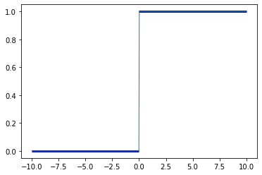

```python
plt.plot(x, x > 0,linewidth=1,clip_on=False);
plt.hlines(xmin=-10,xmax=0,y=0,linewidth=3,color='b')
plt.hlines(xmin=0,xmax=10,y=1,linewidth=3,color='b');
```

# Activation Functions: Sigmoid (Logistic)

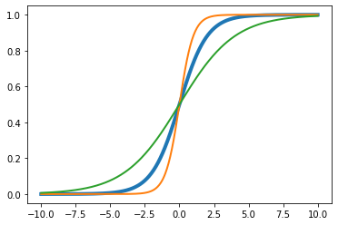

```python
plt.plot(x, 1/(1+np.exp(-x)),linewidth=4,clip_on=False);
plt.plot(x, 1/(1+np.exp(-2*x)),linewidth=2,clip_on=False);
plt.plot(x, 1/(1+np.exp(-.5*x)),linewidth=2,clip_on=False);
```

# Activation Functions: tanh

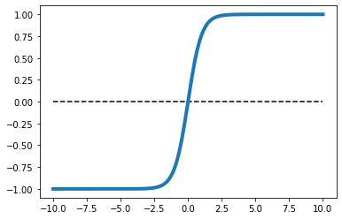

```python
plt.plot([-10,10],[0,0],'k--')
plt.plot(x, np.tanh(x),linewidth=4,clip_on=False);
```

# Activation Functions: ReLU

Rectified Linear Unit: $\sigma(z) = \max(0,z)$

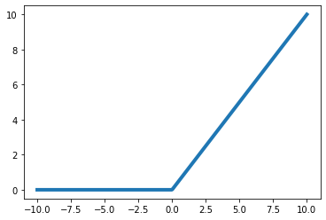

```python
plt.plot(x,x*(x > 0),clip_on=False,linewidth=4);
```

# Networks

[figure not shown]

Terminology alert: networks of neurons are sometimes called *multilayer perceptrons*, despite not using the step function.

```python
%%html
<div id="ibpcnt" style="width: 500px"></div>
<script>
$('head').append('<link rel="stylesheet" href="http://bits.csb.pitt.edu/asker.js/themes/asker.default.css" />');

    var divid = '#ibpcnt';
	jQuery(divid).asker({
	    id: divid,
	    question: "A network has 10 input nodes, two hidden layers each with 10 neurons, and 10 output neurons.  How many parameters does training have to estimate?",
		answers: ["30","100","300","330","600"],
        server: "http://bits.csb.pitt.edu/asker.js/example/asker.cgi",
		charter: chartmaker})

$(".jp-InputArea .o:contains(html)").closest('.jp-InputArea').hide();


</script>
```

# Networks

[figure not shown]

The number of input neurons corresponds to the number of features.

The number of output neurons corresponds to the number of label classes. For binary classification, it is common to have two output nodes.

Layers are typically *fully connected*.

# Neural Networks

The [universal approximation theorem](https://en.wikipedia.org/wiki/Universal_approximation_theorem) says that, if some reasonable assumptions are made, a feedforward neural network with a finite number of nodes can approximate any continuous function to within a given error $\epsilon$ over a bounded input domain.

The theorem says nothing about the design (number of nodes/layers) of such a network.

The theorem says nothing about the *learnability* of the weights of such a network.

These are open theoretical questions.

Given a network design, how are we going to learn weights for the neurons?

# Stochastic Gradient Descent

[figure not shown]

Randomly select $m$ training examples $X_j$ and compute the gradient of the loss function ($L$). Update weights and biases with a given *learning rate* $\eta$. $$ w_k' = w_k-\frac{\eta}{m}\sum_j^m \frac{\partial L_{X_j}}{\partial w_k}$$ $$b_l' = b_l-\frac{\eta}{m} \sum_j^m \frac{\partial L_{X_j}}{\partial b_l} $$

Common loss functions: logistic, hinge, cross entropy, euclidean

# Loss Functions

[figure not shown]

x = 1 is a correct prediction, x = -1 a wrong prediction

# Backpropagation

Backpropagation is an efficient algorithm for computing the partial derivatives needed by the gradient descent update rule. For a training example $x$ and loss function $L$ in a network with $N$ layers:

1. **Feedforward**. For each layer $l$ compute $$a^{l} = \sigma(z^{l})$$ where $z$ is the weighted input and $a$ is the activation induced by $x$ (these are vectors representing all nodes of layer $l$).
2. **Compute output error** $$\delta^{N} = \nabla_a L \odot \sigma'(z^N)$$ where $ \nabla_a L_j = \partial L / \partial a^N_j$, the gradient of the loss with respect to the output activations. $\odot$ is the elementwise product.
3. **Backpropagate the error** $$\delta^{l} = ((w^{l+1})^T \delta^{l+1}) \odot \sigma'(z^{l})$$
4. **Calculate gradients** $$\frac{\partial L}{\partial w^l_{jk}} = a^{l-1}_k \delta^l_j \text{ and } \frac{\partial L}{\partial b^l_j} = \delta^l_j$$

## Backpropagation as the Chain Rule

$$\frac{\partial L}{\partial a^l} \cdot \frac{\partial a^l}{\partial z^l} \cdot \frac{\partial z^l}{\partial a^{l-1}} \cdot \frac{\partial a^{l-1}}{\partial z^{l-1}} \cdot \frac{\partial z^{l-1}}{\partial a^{l-2}} \cdots \frac{\partial a^{1}}{\partial z^{l}} \cdot \frac{\partial z^{l}}{\partial x} $$

# Deep Learning

[figure not shown]

A deep network is not more powerful (recall can approximate any function with a single layer), but may be more concise - can approximate some functions with many fewer nodes.

# Convolutional Neural Nets

[figure not shown]

Image recognition challenge results. Purple are deep learning methods.

# Convolution Filters

A filter applies a *convolution kernel* to an image.

The kernel is represented by an $n$x$n$ matrix where the target pixel is in the center.

The output of the filter is the sum of the products of the matrix elements with the corresponding pixels.

Examples from Wikipedia):

| Identity | Blur | Edge Detection |
| --- | --- | --- |

# Feature Maps

We can think of a kernel as identifying a *feature* in an image and the resulting image as a feature map that has high values (white) where the feature is present and low values (black) elsewhere.

*Feature maps retain the **spatial relationship** between features present in the original image.*

# Convolutional Layers

[figure not shown]

A single kernel is applied across the input. For each output feature map there is a single set of weights.

# Convolutional Layers

For images, each pixel is an input feature. Each hidden layer is a set of feature maps.

[figure not shown]

# Pooling

Pooling layers apply a fixed convolution (usually the non-linear MAX kernel). The kernel is usually applied with a *stride* to reduce the size of the layer.

- faster to train
- fewer parameters to fit
- less sensitive to small changes (MAX)

[figure not shown]

Consider an input image with 100 pixels. In a classic neural network, we hook these pixels up to a hidden layer with 10 nodes. In a CNN, we hook these pixels up to a convolutional layer with a 3x3 kernel and 10 output feature maps.

```python
%%html
<div id="iweightcnt" style="width: 500px"></div>
<script>
$('head').append('<link rel="stylesheet" href="http://bits.csb.pitt.edu/asker.js/themes/asker.default.css" />');

    var divid = '#iweightcnt';
	jQuery(divid).asker({
	    id: divid,
	    question: "Which network has more parameters to learn?",
		answers: ["Classic","CNN"],
        server: "http://bits.csb.pitt.edu/asker.js/example/asker.cgi",
		charter: chartmaker})

$(".jp-InputArea .o:contains(html)").closest('.jp-InputArea').hide();


</script>
```

[figure not shown]

The last features maps are typically connected to one or more fully-connected layers to produce the desired output.

# [PyTorch](https://pytorch.org/)

PyTorch creates the dataflow graph implicitly as operations are performed.

- Dataflow graph can be parallelized
- Dataflow graph maintains **autograd** information - how to compute gradients for backpropagation
- Extremely flexible
- Easier to debug and develop than static approach

# PyTorch Tensors

Tensor is very similar to `numpy.array` in functionality.

- Is allocated to a device (CPU vs GPU)
- Potentially maintains autograd information

```python
import torch  # note package is not called pytorch

T = torch.rand(3,4)
T
```

```
tensor([[0.0406, 0.2614, 0.3920, 0.2542],
        [0.7781, 0.3381, 0.3013, 0.8144],
        [0.7041, 0.2347, 0.4558, 0.3097]])
```

```python
T.shape,T.dtype,T.device,T.requires_grad
```

```
(torch.Size([3, 4]), torch.float32, device(type='cpu'), False)
```

# Modules vs Functional

**Modules** are objects that can be initialized with default parameters and store any learnable parameters. Learnable parameters can be easily extracted from the module (and any member modules). Modules are called as functions on their inputs.

**Functional** APIs maintain no state. All parameters are passed when the function is called.

```python
import torch.nn as nn
import torch.nn.functional as F
```

# A network is a module

To define a network we create a module with submodules for operations with learnable parameters. Generally use functional API for operations without learnable parameters.

```python
class MyNet(nn.Module):
    def __init__(self):  #initialize submodules here - this defines our network architecture
        super(MyNet, self).__init__()
        self.conv1 = nn.Conv2d(in_channels=1, out_channels=32, kernel_size=3, stride=1, padding=1)
        self.conv2 = nn.Conv2d(in_channels=32, out_channels=64, kernel_size=3, stride=1)
        self.fc1 = nn.Linear(2304, 10) #mystery X

    def forward(self, x): # this actually applies the operations
        x = self.conv1(x)
        x = F.relu(x)
        x = F.max_pool2d(x, kernel_size=2, stride=2)  # POOL
        x = self.conv2(x)
        x = F.relu(x)
        x = F.max_pool2d(x, kernel_size=2, stride=2) # POOL
        x = torch.flatten(x, 1)
        x = self.fc1(x)
        return x
```

# MNIST

```python
from torchvision import datasets
train_data = datasets.MNIST(root='../data', train=True)
test_data = datasets.MNIST(root='../data', train=False)
```

```python
train_data[0]
```

```
(<PIL.Image.Image image mode=L size=28x28 at 0x7FE3B3C93D90>, 5)
```

```python
train_data[0][0]
```

Inputs need to be tensors...

```python
from torchvision import transforms
train_data = datasets.MNIST(root='../data', train=True,transform=transforms.ToTensor())
test_data = datasets.MNIST(root='../data', train=False,transform=transforms.ToTensor())
```

```python
train_data[0][0]
```

```
tensor([[[0.0000, 0.0000, 0.0000, 0.0000, 0.0000, 0.0000, 0.0000, 0.0000,
          0.0000, 0.0000, 0.0000, 0.0000, 0.0000, 0.0000, 0.0000, 0.0000,
          0.0000, 0.0000, 0.0000, 0.0000, 0.0000, 0.0000, 0.0000, 0.0000,
          0.0000, 0.0000, 0.0000, 0.0000],
         [0.0000, 0.0000, 0.0000, 0.0000, 0.0000, 0.0000, 0.0000, 0.0000,
          0.0000, 0.0000, 0.0000, 0.0000, 0.0000, 0.0000, 0.0000, 0.0000,
          0.0000, 0.0000, 0.0000, 0.0000, 0.0000, 0.0000, 0.0000, 0.0000,
          0.0000, 0.0000, 0.0000, 0.0000],
         [0.0000, 0.0000, 0.0000, 0.0000, 0.0000, 0.0000, 0.0000, 0.0000,
          0.0000, 0.0000, 0.0000, 0.0000, 0.0000, 0.0000, 0.0000, 0.0000,
          0.0000, 0.0000, 0.0000, 0.0000, 0.0000, 0.0000, 0.0000, 0.0000,
          0.0000, 0.0000, 0.0000, 0.0000],
         [0.0000, 0.0000, 0.0000, 0.0000, 0.0000, 0.0000, 0.0000, 0.0000,
          0.0000, 0.0000, 0.0000, 0.0000, 0.0000, 0.0000, 0.0000, 0.0000,
          0.0000, 0.0000, 0.0000, 0.0000, 0.0000, 0.0000, 0.0000, 0.0000,
          0.0000, 0.0000, 0.0000, 0.0000],
         [0.0000, 0.0000, 0.0000, 0.0000, 0.0000, 0.0000, 0.0000, 0.0000,
          0.0000, 0.0000, 0.0000, 0.0000, 0.0000, 0.0000, 0.0000, 0.0000,
          0.0000, 0.0000, 0.0000, 0.0000, 0.0000, 0.0000, 0.0000, 0.0000,
          0.0000, 0.0000, 0.0000, 0.0000],
         [0.0000, 0.0000, 0.0000, 0.0000, 0.0000, 0.0000, 0.0000, 0.0000,
          0.0000, 0.0000, 0.0000, 0.0000, 0.0118, 0.0706, 0.0706, 0.0706,
          0.4941, 0.5333, 0.6863, 0.1020, 0.6510, 1.0000, 0.9686, 0.4980,
          0.0000, 0.0000, 0.0000, 0.0000],
         [0.0000, 0.0000, 0.0000, 0.0000, 0.0000, 0.0000, 0.0000, 0.0000,
          0.1176, 0.1412, 0.3686, 0.6039, 0.6667, 0.9922, 0.9922, 0.9922,
          0.9922, 0.9922, 0.8824, 0.6745, 0.9922, 0.9490, 0.7647, 0.2510,
          0.0000, 0.0000, 0.0000, 0.0000],
         [0.0000, 0.0000, 0.0000, 0.0000, 0.0000, 0.0000, 0.0000, 0.1922,
          0.9333, 0.9922, 0.9922, 0.9922, 0.9922, 0.9922, 0.9922, 0.9922,
          0.9922, 0.9843, 0.3647, 0.3216, 0.3216, 0.2196, 0.1529, 0.0000,
          0.0000, 0.0000, 0.0000, 0.0000],
         [0.0000, 0.0000, 0.0000, 0.0000, 0.0000, 0.0000, 0.0000, 0.0706,
          0.8588, 0.9922, 0.9922, 0.9922, 0.9922, 0.9922, 0.7765, 0.7137,
          0.9686, 0.9451, 0.0000, 0.0000, 0.0000, 0.0000, 0.0000, 0.0000,
          0.0000, 0.0000, 0.0000, 0.0000],
         [0.0000, 0.0000, 0.0000, 0.0000, 0.0000, 0.0000, 0.0000, 0.0000,
          0.3137, 0.6118, 0.4196, 0.9922, 0.9922, 0.8039, 0.0431, 0.0000,
          0.1686, 0.6039, 0.0000, 0.0000, 0.0000, 0.0000, 0.0000, 0.0000,
          0.0000, 0.0000, 0.0000, 0.0000],
```

[output cut: 57 more lines]

```
          0.8314, 0.5294, 0.5176, 0.0627, 0.0000, 0.0000, 0.0000, 0.0000,
          0.0000, 0.0000, 0.0000, 0.0000, 0.0000, 0.0000, 0.0000, 0.0000,
          0.0000, 0.0000, 0.0000, 0.0000],
         [0.0000, 0.0000, 0.0000, 0.0000, 0.0000, 0.0000, 0.0000, 0.0000,
          0.0000, 0.0000, 0.0000, 0.0000, 0.0000, 0.0000, 0.0000, 0.0000,
          0.0000, 0.0000, 0.0000, 0.0000, 0.0000, 0.0000, 0.0000, 0.0000,
          0.0000, 0.0000, 0.0000, 0.0000],
         [0.0000, 0.0000, 0.0000, 0.0000, 0.0000, 0.0000, 0.0000, 0.0000,
          0.0000, 0.0000, 0.0000, 0.0000, 0.0000, 0.0000, 0.0000, 0.0000,
          0.0000, 0.0000, 0.0000, 0.0000, 0.0000, 0.0000, 0.0000, 0.0000,
          0.0000, 0.0000, 0.0000, 0.0000],
         [0.0000, 0.0000, 0.0000, 0.0000, 0.0000, 0.0000, 0.0000, 0.0000,
          0.0000, 0.0000, 0.0000, 0.0000, 0.0000, 0.0000, 0.0000, 0.0000,
          0.0000, 0.0000, 0.0000, 0.0000, 0.0000, 0.0000, 0.0000, 0.0000,
          0.0000, 0.0000, 0.0000, 0.0000]]])
```

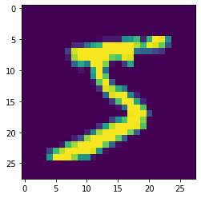

```python
plt.imshow(train_data[0][0][0])
```

# Training MNIST

```python
#process 10 randomly sampled images at a time
train_loader = torch.utils.data.DataLoader(train_data,batch_size=10,shuffle=True)
test_loader = torch.utils.data.DataLoader(test_data,batch_size=10,shuffle=False)

#instantiate our neural network and put it on the GPU
model = MyNet().to('cuda')
```

```python
batch = next(iter(train_loader))
batch
```

```
[tensor([[[[0., 0., 0.,  ..., 0., 0., 0.],
           [0., 0., 0.,  ..., 0., 0., 0.],
           [0., 0., 0.,  ..., 0., 0., 0.],
           ...,
           [0., 0., 0.,  ..., 0., 0., 0.],
           [0., 0., 0.,  ..., 0., 0., 0.],
           [0., 0., 0.,  ..., 0., 0., 0.]]],


         [[[0., 0., 0.,  ..., 0., 0., 0.],
           [0., 0., 0.,  ..., 0., 0., 0.],
           [0., 0., 0.,  ..., 0., 0., 0.],
           ...,
           [0., 0., 0.,  ..., 0., 0., 0.],
           [0., 0., 0.,  ..., 0., 0., 0.],
           [0., 0., 0.,  ..., 0., 0., 0.]]],


         [[[0., 0., 0.,  ..., 0., 0., 0.],
           [0., 0., 0.,  ..., 0., 0., 0.],
           [0., 0., 0.,  ..., 0., 0., 0.],
           ...,
           [0., 0., 0.,  ..., 0., 0., 0.],
           [0., 0., 0.,  ..., 0., 0., 0.],
           [0., 0., 0.,  ..., 0., 0., 0.]]],


         ...,


         [[[0., 0., 0.,  ..., 0., 0., 0.],
           [0., 0., 0.,  ..., 0., 0., 0.],
           [0., 0., 0.,  ..., 0., 0., 0.],
           ...,
           [0., 0., 0.,  ..., 0., 0., 0.],
           [0., 0., 0.,  ..., 0., 0., 0.],
           [0., 0., 0.,  ..., 0., 0., 0.]]],


         [[[0., 0., 0.,  ..., 0., 0., 0.],
           [0., 0., 0.,  ..., 0., 0., 0.],
           [0., 0., 0.,  ..., 0., 0., 0.],
           ...,
           [0., 0., 0.,  ..., 0., 0., 0.],
           [0., 0., 0.,  ..., 0., 0., 0.],
           [0., 0., 0.,  ..., 0., 0., 0.]]],


         [[[0., 0., 0.,  ..., 0., 0., 0.],
           [0., 0., 0.,  ..., 0., 0., 0.],
           [0., 0., 0.,  ..., 0., 0., 0.],
           ...,
           [0., 0., 0.,  ..., 0., 0., 0.],
           [0., 0., 0.,  ..., 0., 0., 0.],
           [0., 0., 0.,  ..., 0., 0., 0.]]]]),
 tensor([4, 8, 3, 8, 0, 5, 0, 6, 3, 6])]
```

```python
output = model(batch[0].to('cuda')) # model is on GPU, so must put input there too
output
```

```
tensor([[ 3.1438e-02, -3.9091e-03, -3.6213e-02,  2.8207e-02,  3.1137e-02,
          2.2839e-02, -9.1202e-02,  1.2138e-01,  1.8157e-02, -5.4731e-03],
        [ 5.1647e-02, -1.3989e-02, -5.8817e-02,  7.8382e-02,  1.3369e-03,
         -8.5472e-03, -5.5788e-02,  1.8370e-01, -1.4171e-02,  5.8946e-02],
        [ 6.4755e-02,  2.1220e-02, -5.9609e-02,  4.9725e-02, -1.6778e-02,
          4.5223e-03, -1.0365e-01,  1.6527e-01, -1.1577e-02,  8.8502e-03],
        [ 4.9331e-02,  4.3144e-02, -8.3948e-02,  6.0377e-02,  2.1370e-02,
          9.5168e-03, -5.3153e-02,  1.8266e-01, -3.7884e-02,  5.1163e-02],
        [ 1.0056e-01, -7.3998e-02, -2.2378e-02,  2.5610e-02,  6.5865e-02,
         -1.3075e-03, -7.6474e-02,  2.0313e-01, -5.0937e-03, -5.9268e-03],
        [ 4.9978e-02, -3.7414e-02, -4.8822e-02,  3.2775e-02, -9.8386e-03,
          1.9825e-02, -1.2044e-01,  1.5980e-01, -5.9759e-03,  9.0554e-03],
        [ 6.0837e-02, -4.9022e-02, -7.7478e-02,  6.8185e-02,  6.6045e-02,
         -1.4132e-02, -9.0710e-02,  2.4664e-01, -3.3374e-02,  9.1609e-03],
        [ 7.4179e-02,  3.8928e-02, -5.2672e-02,  4.0418e-02,  1.8892e-02,
         -2.4019e-04, -1.0321e-01,  1.3379e-01, -1.8316e-02,  1.5860e-02],
        [ 4.6565e-02,  4.0759e-03, -4.7199e-02,  5.2782e-02,  2.8811e-02,
         -1.2185e-02, -7.4558e-02,  2.0798e-01, -4.1917e-02,  3.0762e-02],
        [ 9.5145e-02,  5.9286e-02, -5.7390e-02,  4.3711e-02,  2.9238e-02,
         -5.0172e-02, -7.5495e-02,  1.7137e-01, -1.4601e-02,  2.7963e-02]],
       device='cuda:0', grad_fn=<AddmmBackward>)
```

# Training MNIST

Our network takes an image (as a tensor) and outputs class probabilities.

- Need a loss
- Need an optimizer (e.g. SGD, ADAM)
  - `backward` does *not* update parameters

```python
loss = F.cross_entropy(output,batch[1].to('cuda')) #combines log softmax and
loss
```

```
tensor(2.3140, device='cuda:0', grad_fn=<NllLossBackward>)
```

$$L(x,class) = - \log\left(\frac{e^{x_{\mathrm{class}}}}{\sum_j e^{x_j}}\right)$$

```python
loss.backward() # sets grad, but does not change parameters of model
```

# Training MNIST

**Epoch** - One pass through the training data.

```python
%%time
optimizer = torch.optim.Adam(model.parameters(), lr=0.00001) # need to tell optimizer what it is optimizing

losses = []
for epoch in range(10):
    for i, (img,label) in enumerate(train_loader):
        optimizer.zero_grad()  # IMPORTANT!
        img, label = img.to('cuda'), label.to('cuda')
        output = model(img)
        loss = F.cross_entropy(output, label)
        loss.backward()
        optimizer.step()
        losses.append(loss.item())
```

```
CPU times: user 2min 42s, sys: 1.33 s, total: 2min 43s
Wall time: 2min 40s
```

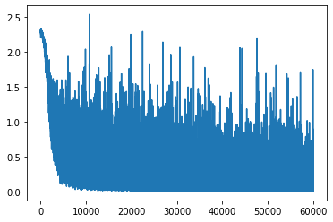

```python
plt.plot(losses)
```

This is the **batch loss**.

# Testing MNIST

```python
correct = 0
with torch.no_grad(): #no need for gradients - won't be calling backward to clear them
    for img, label in test_loader:
        img, label = img.to('cuda'), label.to('cuda')
        output = F.softmax(model(img),dim=1)
        pred = output.argmax(dim=1, keepdim=True)  # get the index of the max log-probability
        correct += pred.eq(label.view_as(pred)).sum().item()

print("Accuracy",correct/len(test_loader.dataset))
```

```
Accuracy 0.9714
```

# Some Failures

*Not from this particular network

[figure not shown]

Top label is correct. Bottom is prediction from a CNN.

# Generative vs. Discriminative

A *generative* model produces as output the input of a discriminative model: $P(X|Y=y)$ *or* $P(X,Y)$

$y \rightarrow$

Model

$ \rightarrow X$

Model

$ \rightarrow X,y$

# Autoencoders

A neural network trained to generate its input.

[figure not shown]

https://en.wikipedia.org/wiki/Autoencoder

# Latent Space

http://blog.fastforwardlabs.com/2016/08/12/introducing-variational-autoencoders-in-prose-and.html

[figure not shown]

# Latent Space Arithmetic

https://arxiv.org/pdf/1707.05776.pdf

[figure not shown]

# Latent Spaces for Molecules

https://arxiv.org/abs/1610.02415

| 1% - 70% of output valid SMILES |  |
| --- | --- |

# Generative Models of the Cell

https://arxiv.org/pdf/1705.00092.pdf

https://drive.google.com/file/d/0B2tsfjLgpFVhMnhwUVVuQnJxZTg/view

# Generative Adversarial Networks

https://arxiv.org/abs/1406.2661

[figure not shown]

https://youtu.be/G06dEcZ-QTg

https://thispersondoesnotexist.com

[figure not shown]

# pix2pix

[figure not shown]

https://affinelayer.com/pixsrv/

https://github.com/junyanz/pytorch-CycleGAN-and-pix2pix

# CycleGAN

https://medium.com/coding-blocks/introduction-to-cyclegans-1dbdb8fbe781

[figure not shown]

https://techcrunch.com/2018/12/31/this-clever-ai-hid-data-from-its-creators-to-cheat-at-its-appointed-task/

[figure not shown]

## Deep learning is not profound learning.

But it is quite powerful and flexible.